# Hotel_pricing In Indian Market

tavva_prudhvith

January 26, 2018

The purpose of this project is to analyse the pricing strategy of hotels in the Indian hotel industry. Many factors drive hotel room prices. The objective of this project is to identify the factors that matter the most. Think about the following problem: Room Rent = FUNCTION ( Date(s); Hotel Features; External Factors)

## Sumarize the data.

```r
hotel<-read.csv(file.choose(),header=T)
summary(hotel)
```

```
##       CityName      Population          CityRank      IsMetroCity
##  Delhi    :2048   Min.   :    8096   Min.   : 0.00   Min.   :0.0000
##  Jaipur   : 768   1st Qu.:  744983   1st Qu.: 2.00   1st Qu.:0.0000
##  Mumbai   : 712   Median : 3046163   Median : 9.00   Median :0.0000
##  Bangalore: 656   Mean   : 4416837   Mean   :14.83   Mean   :0.2842
##  Goa      : 624   3rd Qu.: 8443675   3rd Qu.:24.00   3rd Qu.:1.0000
##  Kochi    : 608   Max.   :12442373   Max.   :44.00   Max.   :1.0000
##  (Other)  :7816
##  IsTouristDestination   IsWeekend       IsNewYearEve             Date
##  Min.   :0.0000       Min.   :0.0000   Min.   :0.0000   Dec 21 2016:1611
##  1st Qu.:0.0000       1st Qu.:0.0000   1st Qu.:0.0000   Dec 24 2016:1611
##  Median :1.0000       Median :1.0000   Median :0.0000   Dec 25 2016:1611
##  Mean   :0.6972       Mean   :0.6228   Mean   :0.1244   Dec 28 2016:1611
##  3rd Qu.:1.0000       3rd Qu.:1.0000   3rd Qu.:0.0000   Dec 31 2016:1611
##  Max.   :1.0000       Max.   :1.0000   Max.   :1.0000   Dec 18 2016:1608
##                                                         (Other)    :3569
##                   HotelName        RoomRent        StarRating
##  Vivanta by Taj        :   32   Min.   :   299   Min.   :0.000
##  Goldfinch Hotel       :   24   1st Qu.:  2436   1st Qu.:3.000
##  OYO Rooms             :   24   Median :  4000   Median :3.000
##  The Gordon House Hotel:   24   Mean   :  5474   Mean   :3.459
##  Apnayt Villa          :   16   3rd Qu.:  6299   3rd Qu.:4.000
##  Bentleys Hotel Colaba :   16   Max.   :322500   Max.   :5.000
##  (Other)               :13096
##     Airport
##  Min.   :  0.20
##  1st Qu.:  8.40
##  Median : 15.00
##  Mean   : 21.16
##  3rd Qu.: 24.00
##  Max.   :124.00
##
##                                                                    HotelAddress
##  The Mall, Shimla                                                        :   32
##  #2-91/14/8, White Fields, Kondapur, Hitech City, Hyderabad, 500084 India:   16
##  121, City Terrace, Walchand Hirachand Marg, Mumbai, Maharashtra         :   16
##  14-4507/9, Balmatta Road, Near Jyothi Circle, Hampankatta               :   16
##  144/7, Rajiv Gandi Salai (OMR), Kottivakkam, Chennai, Tamil Nadu        :   16
##  17, Oliver Road, Colaba, Mumbai, Maharashtra                            :   16
##  (Other)                                                                 :13120
##   HotelPincode         HotelDescription    FreeWifi      FreeBreakfast
##  Min.   : 100025   3           :  120   Min.   :0.0000   Min.   :0.0000
##  1st Qu.: 221001   Abc         :  112   1st Qu.:1.0000   1st Qu.:0.0000
##  Median : 395003   3-star hotel:  104   Median :1.0000   Median :1.0000
##  Mean   : 397430   3.5         :   88   Mean   :0.9259   Mean   :0.6491
##  3rd Qu.: 570001   4           :   72   3rd Qu.:1.0000   3rd Qu.:1.0000
##  Max.   :7000157   (Other)     :12728   Max.   :1.0000   Max.   :1.0000
##                    NA's        :    8
##  HotelCapacity    HasSwimmingPool
##  Min.   :  0.00   Min.   :0.0000
##  1st Qu.: 16.00   1st Qu.:0.0000
##  Median : 34.00   Median :0.0000
##  Mean   : 62.51   Mean   :0.3558
##  3rd Qu.: 75.00   3rd Qu.:1.0000
##  Max.   :600.00   Max.   :1.0000
##
```

```r
library(psych)
describe(hotel)
```

```
##                      vars     n       mean         sd  median    trimmed
## CityName*               1 13232      18.07      11.72      16      17.29
## Population              2 13232 4416836.87 4258386.00 3046163 4040816.22
## CityRank                3 13232      14.83      13.51       9      13.30
## IsMetroCity             4 13232       0.28       0.45       0       0.23
## IsTouristDestination    5 13232       0.70       0.46       1       0.75
## IsWeekend               6 13232       0.62       0.48       1       0.65
## IsNewYearEve            7 13232       0.12       0.33       0       0.03
## Date*                   8 13232      14.30       2.69      14      14.39
## HotelName*              9 13232     841.19     488.16     827     841.18
## RoomRent               10 13232    5473.99    7333.12    4000    4383.33
## StarRating             11 13232       3.46       0.76       3       3.40
## Airport                12 13232      21.16      22.76      15      16.39
## HotelAddress*          13 13232    1202.53     582.17    1261    1233.25
## HotelPincode           14 13232  397430.26  259837.50  395003  388540.47
## HotelDescription*      15 13224     581.34     363.26     567     575.37
## FreeWifi               16 13232       0.93       0.26       1       1.00
## FreeBreakfast          17 13232       0.65       0.48       1       0.69
## HotelCapacity          18 13232      62.51      76.66      34      46.03
## HasSwimmingPool        19 13232       0.36       0.48       0       0.32
##                             mad      min      max      range  skew
## CityName*                 11.86      1.0       42       41.0  0.48
## Population           3846498.95   8096.0 12442373 12434277.0  0.68
## CityRank                  11.86      0.0       44       44.0  0.69
## IsMetroCity                0.00      0.0        1        1.0  0.96
## IsTouristDestination       0.00      0.0        1        1.0 -0.86
## IsWeekend                  0.00      0.0        1        1.0 -0.51
## IsNewYearEve               0.00      0.0        1        1.0  2.28
## Date*                      2.97      1.0       20       19.0 -0.77
## HotelName*               641.97      1.0     1670     1669.0  0.01
## RoomRent                2653.85    299.0   322500   322201.0 16.75
## StarRating                 0.74      0.0        5        5.0  0.48
## Airport                   11.12      0.2      124      123.8  2.73
## HotelAddress*            668.65      1.0     2108     2107.0 -0.37
## HotelPincode          257975.37 100025.0  7000157  6900132.0  9.99
## HotelDescription*        472.95      1.0     1226     1225.0  0.11
## FreeWifi                   0.00      0.0        1        1.0 -3.25
## FreeBreakfast              0.00      0.0        1        1.0 -0.62
## HotelCapacity             28.17      0.0      600      600.0  2.95
## HasSwimmingPool            0.00      0.0        1        1.0  0.60
##                      kurtosis       se
## CityName*               -0.88     0.10
## Population              -1.08 37019.65
## CityRank                -0.76     0.12
## IsMetroCity             -1.08     0.00
## IsTouristDestination    -1.26     0.00
## IsWeekend               -1.74     0.00
## IsNewYearEve             3.18     0.00
## Date*                    1.92     0.02
## HotelName*              -1.25     4.24
## RoomRent               582.06    63.75
## StarRating               0.25     0.01
## Airport                  7.89     0.20
## HotelAddress*           -0.88     5.06
## HotelPincode           249.76  2258.86
## HotelDescription*       -1.25     3.16
## FreeWifi                 8.57     0.00
## FreeBreakfast           -1.61     0.00
## HotelCapacity           11.39     0.67
## HasSwimmingPool         -1.64     0.00
```

```r
#Apply Some Functions
aggregate(hotel$RoomRent, by=list(freewifi = hotel$FreeWifi, freeBreakfast = hotel$FreeBreakfast, swimmingPool = hotel$HasSwimmingPool,Touristplace=hotel$IsTouristDestination), mean)
```

```
##    freewifi freeBreakfast swimmingPool Touristplace         x
## 1         0             0            0            0  2961.188
## 2         1             0            0            0  2788.815
## 3         0             1            0            0  4108.600
## 4         1             1            0            0  3286.387
## 5         0             0            1            0  7185.167
## 6         1             0            1            0  6675.889
## 7         0             1            1            0  5079.913
## 8         1             1            1            0  5517.907
## 9         0             0            0            1  3677.939
## 10        1             0            0            1  3257.897
## 11        0             1            0            1  5909.478
## 12        1             1            0            1  4395.936
## 13        0             0            1            1  7446.194
## 14        1             0            1            1 10818.984
## 15        0             1            1            1  5240.216
## 16        1             1            1            1  9215.152
```

## One-Way Contingency Tables for categorial variables

```r
table1<-with(hotel,table(FreeWifi))
table1
```

```
## FreeWifi
##     0     1
##   981 12251
```

```r
prop.table(table1)*100 # Percentage For Free-Wifi
```

```
## FreeWifi
##         0         1
##  7.413845 92.586155
```

```r
table2<-with(hotel,table(HasSwimmingPool))
table2
```

```
## HasSwimmingPool
##    0    1
## 8524 4708
```

```r
prop.table(table2)*100 #Percentage for Hotels which have swimming pools.
```

```
## HasSwimmingPool
##        0        1
## 64.41959 35.58041
```

```r
table3<-with(hotel,table(FreeBreakfast))
table3
```

```
## FreeBreakfast
##    0    1
## 4643 8589
```

```r
prop.table(table3)*100 # Percentage For Free Breakfast
```

```
## FreeBreakfast
##        0        1
## 35.08918 64.91082
```

```r
table4<-with(hotel,table(IsTouristDestination))
table4
```

```
## IsTouristDestination
##    0    1
## 4007 9225
```

```r
prop.table(table4)*100 # Percentage For Hotels which is a Tourist Destination.
```

```
## IsTouristDestination
##        0        1
## 30.28265 69.71735
```

# Two-Way Contingency tables for categorial variables.

```r
table5<-xtabs(~hotel$IsTouristDestination + hotel$IsWeekend)
table5
```

```
##                           hotel$IsWeekend
## hotel$IsTouristDestination    0    1
##                          0 1454 2553
##                          1 3537 5688
```

```r
table6<-xtabs(~hotel$StarRating + hotel$IsMetroCity)
table6
```

```
##                 hotel$IsMetroCity
## hotel$StarRating    0    1
##              0     16    0
##              1      8    0
##              2    344   96
##              2.5  456  176
##              3   4336 1617
##              3.2    8    0
##              3.3   16    0
##              3.4    8    0
##              3.5 1312  440
##              3.6    0    8
##              3.7   24    0
##              3.8   16    0
##              3.9   32    0
##              4   1696  767
##              4.1   24    0
##              4.3   16    0
##              4.4    8    0
##              4.5  288   88
##              4.7    8    0
##              4.8   16    0
##              5    840  568
```

```r
table7<-xtabs(~hotel$StarRating + hotel$IsTouristDestination)
table7
```

```
##                 hotel$IsTouristDestination
## hotel$StarRating    0    1
##              0      0   16
##              1      0    8
##              2     64  376
##              2.5  152  480
##              3   1888 4065
##              3.2    0    8
##              3.3    0   16
##              3.4    0    8
##              3.5  448 1304
##              3.6    0    8
##              3.7    8   16
##              3.8   16    0
##              3.9   16   16
##              4    839 1624
##              4.1    0   24
##              4.3   16    0
##              4.4    8    0
##              4.5  128  248
##              4.7    8    0
##              4.8    0   16
##              5    416  992
```

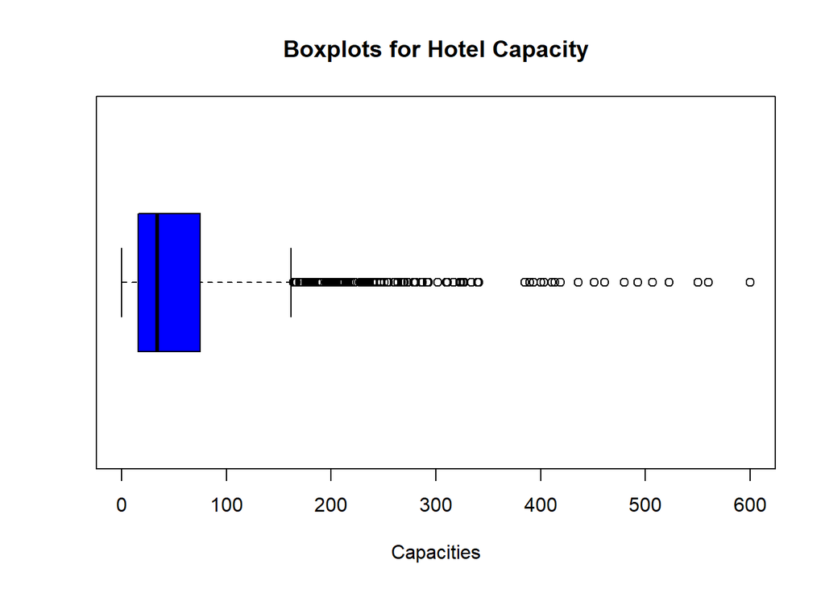

```r
# Boxplot For Capacity.
boxplot(hotel$HotelCapacity,
    main="Boxplots for Hotel Capacity",
    col="blue",
    horizontal = T,
    xlab="Capacities")
```

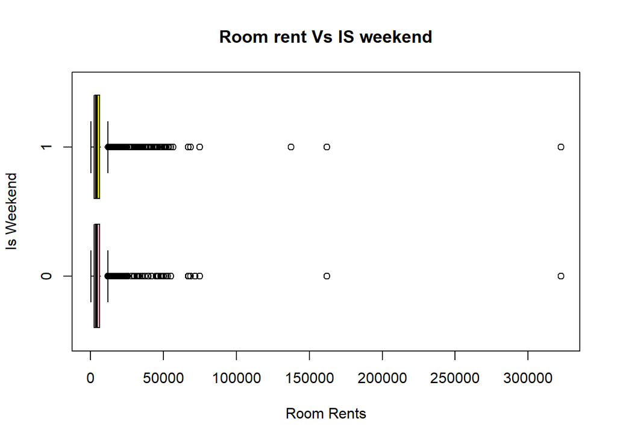

```r
#Boxplot for Room rent and Weekends.
boxplot(hotel$RoomRent ~ hotel$IsWeekend,
        horizontal=T,
        main="Room rent Vs IS weekend",
        xlab="Room Rents",
        ylab="Is Weekend",
col=c("pink","yellow"))
```

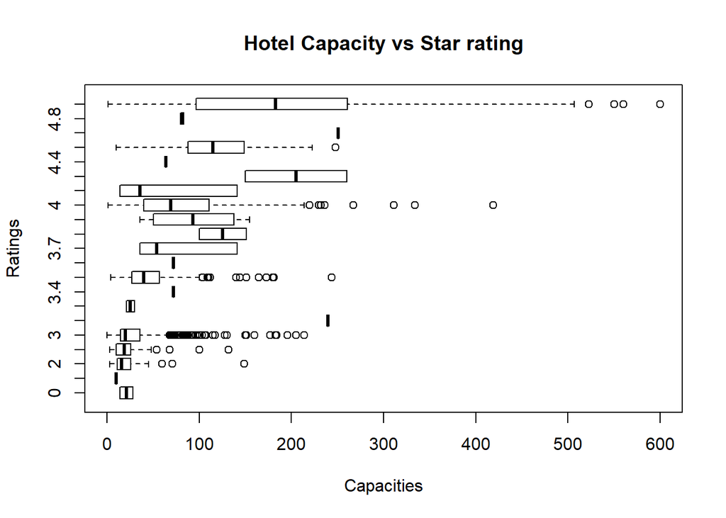

```r
#Boxplots For Capacity and rating OF th Hotels.
boxplot(hotel$HotelCapacity ~ hotel$StarRating,
        horizontal=T,
        main="Hotel Capacity vs Star rating",
        xlab="Capacities",
        ylab="Ratings")
```

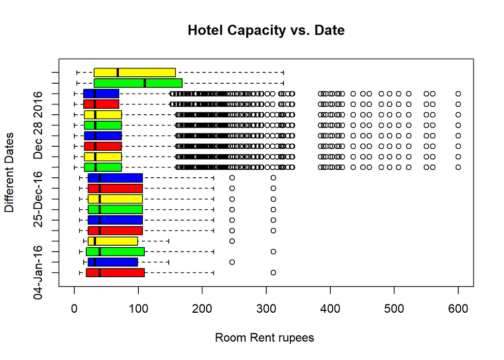

```r
#boxplots FOr Hotel Capacity and Date.
boxplot(hotel$HotelCapacity~hotel$Date,
        main="Hotel Capacity vs. Date",
        ylab="Different Dates",
        xlab="Room Rent rupees ",
        col=c("red","blue","green","yellow"),
        horizontal=TRUE)
```

## Histograms Of Suitable Data

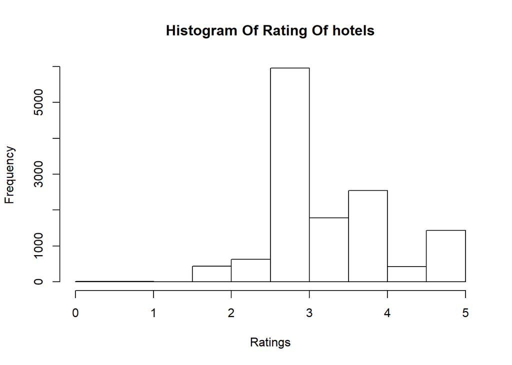

```r
# Histogram Of ratings For Hotels
hist(hotel$StarRating,
     main="Histogram Of Rating Of hotels",
     xlab="Ratings",
     breaks=10)
```

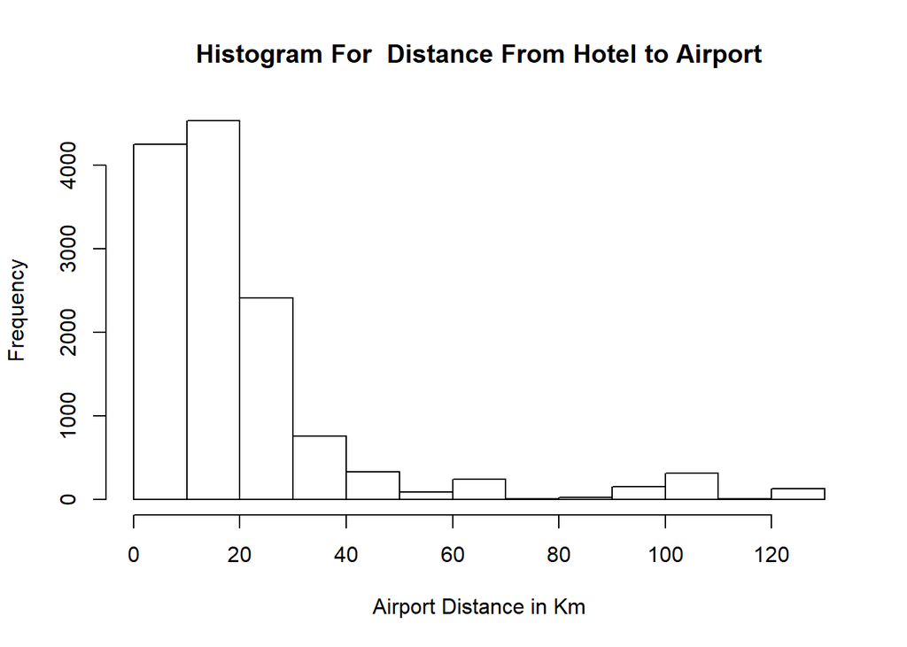

```r
# Histograms for Distance Between Hotel to Airport.
hist(hotel$Airport,
     main="Histogram For  Distance From Hotel to Airport",
     xlab="Airport Distance in Km")
```

```r
# Using Histogram command using lattice package to find the distributions of Date variable.
table(hotel$Date)
```

```
##
##   04-Jan-16   04-Jan-17   08-Jan-16   08-Jan-17   18-Dec-16   21-Dec-16
##          31          13          31          13          44          44
##   24-Dec-16   25-Dec-16   28-Dec-16   31-Dec-16 Dec 18 2016 Dec 21 2016
##          44          44          44          44        1608        1611
## Dec 24 2016 Dec 25 2016 Dec 28 2016 Dec 31 2016 Jan 04 2017 Jan 08 2017
##        1611        1611        1611        1611        1548        1542
##  Jan 4 2017  Jan 8 2017
##          60          67
```

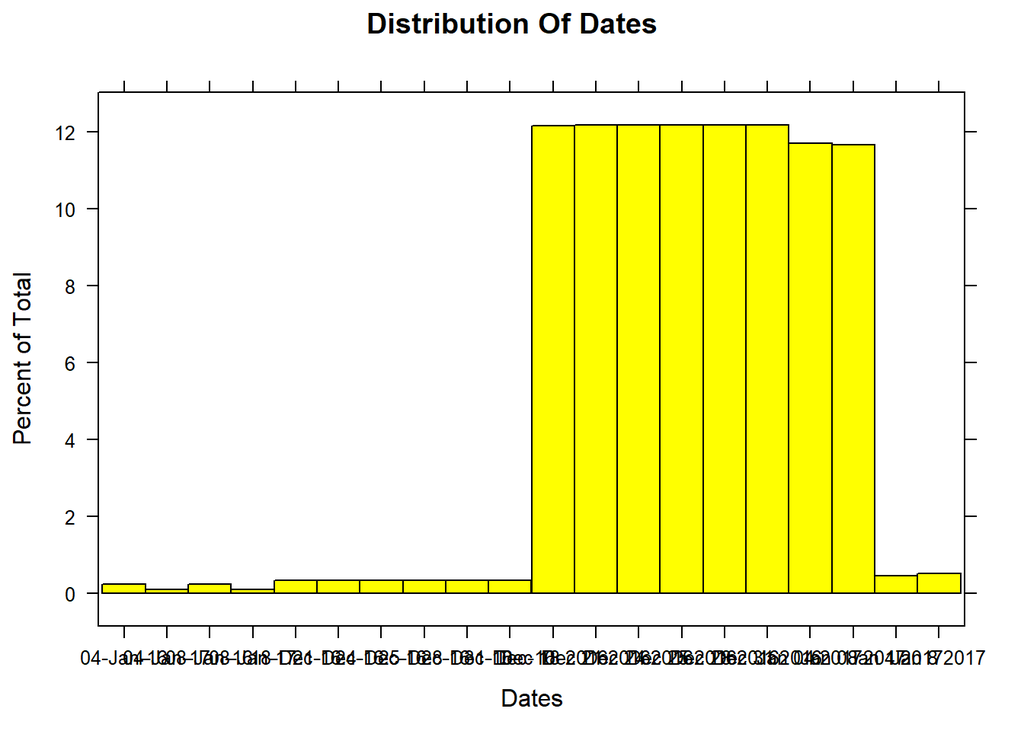

```r
library(lattice)
histogram(~Date,data=hotel,
          main="Distribution Of Dates",
          xlab="Dates",
          col="yellow")
```

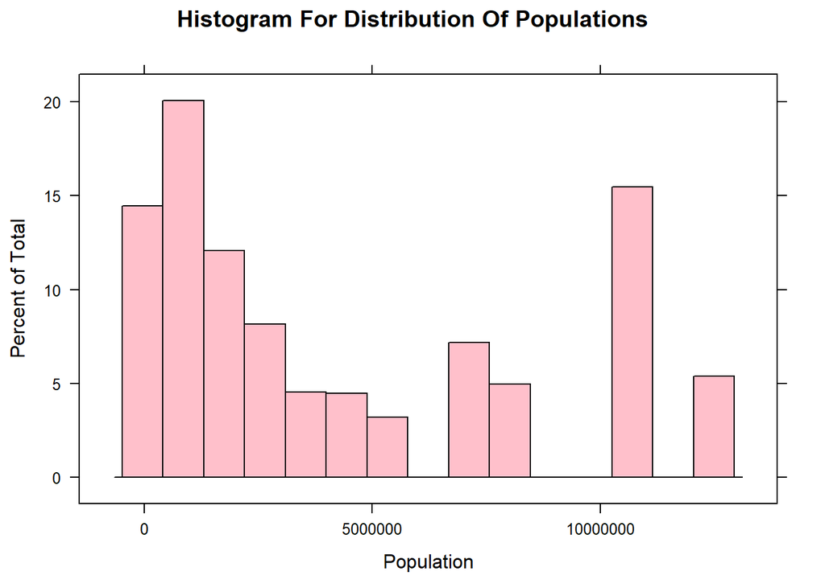

```r
# Using Histogram command using lattice package to find the distributions of population variable.
histogram(~Population,
          data=hotel,
          main="Histogram For Distribution Of Populations",
          col="pink")
```

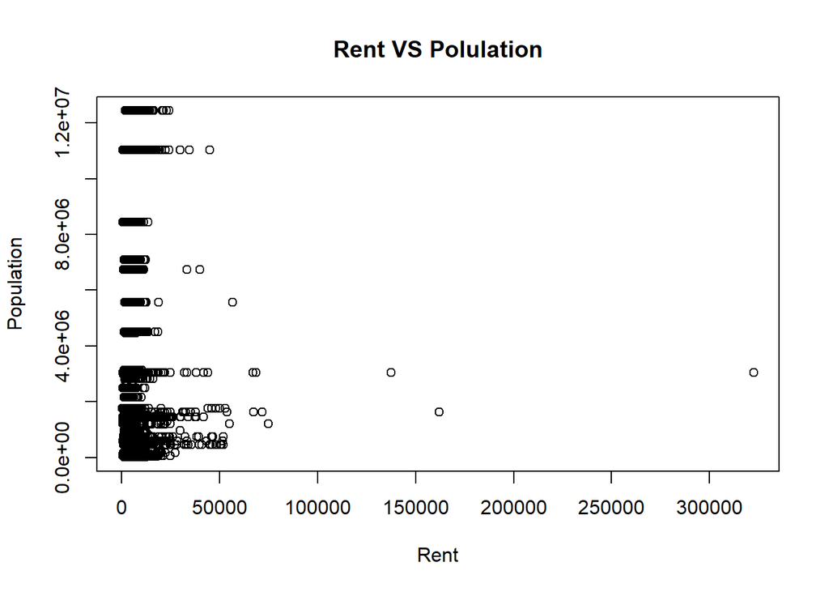

```r
plot(hotel$RoomRent,
     hotel$Population,
     main="Rent VS Polulation",
     xlab="Rent",
     ylab="Population")
```

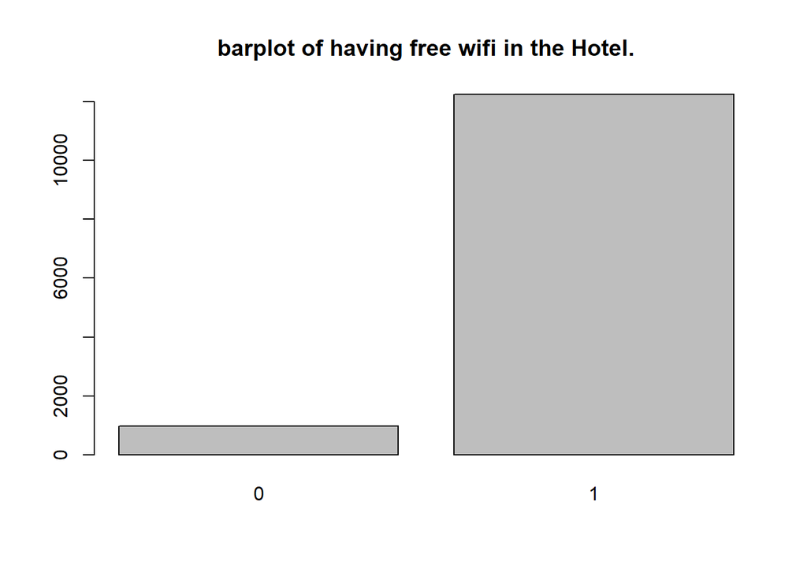

```r
# Including the ones which have free wifi in hotels.
freewifi<-table(hotel$FreeWifi)
barplot(freewifi,
        main="barplot of having free wifi in the Hotel.")
```

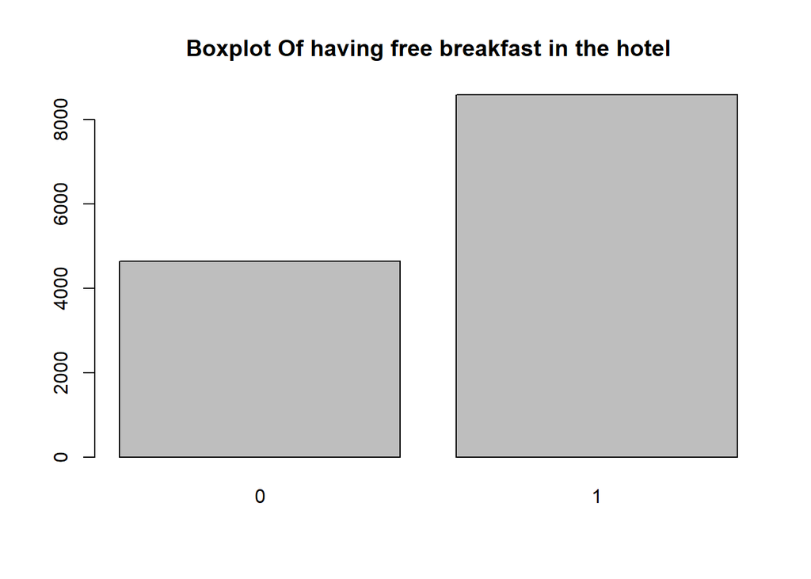

```r
#Including the ones which have free breakfast in the hotels.
breakfast<-table(hotel$FreeBreakfast)
barplot(breakfast,
        main="Boxplot Of having free breakfast in the hotel")
```

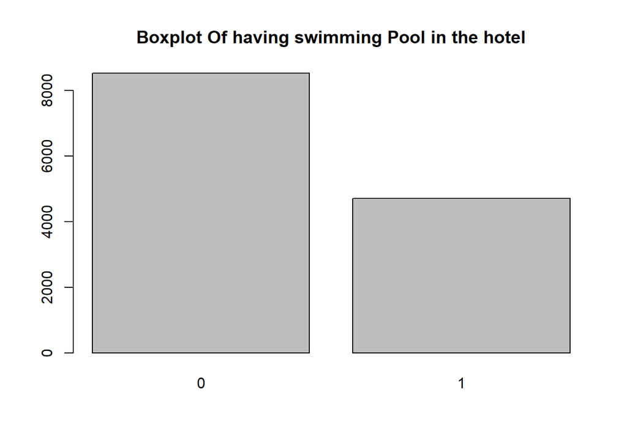

```r
#Including the ones which have swimming pool in the hotels.
pool<-table(hotel$HasSwimmingPool)
barplot(pool,
        main="Boxplot Of having swimming Pool in the hotel")
```

Conclusion For the Above Plots and Barplots: 1.freewifi-According to the graph,there are more hotels having free wifi than the ones who doesn’t have wifi. 2.breakfast-According to the graph,there are more hotels who give free breakfast than the ones who doesn’t give breakfast. 3.pool-According to the graph,there are less number of hotels who have a swimming pool in their hotel.

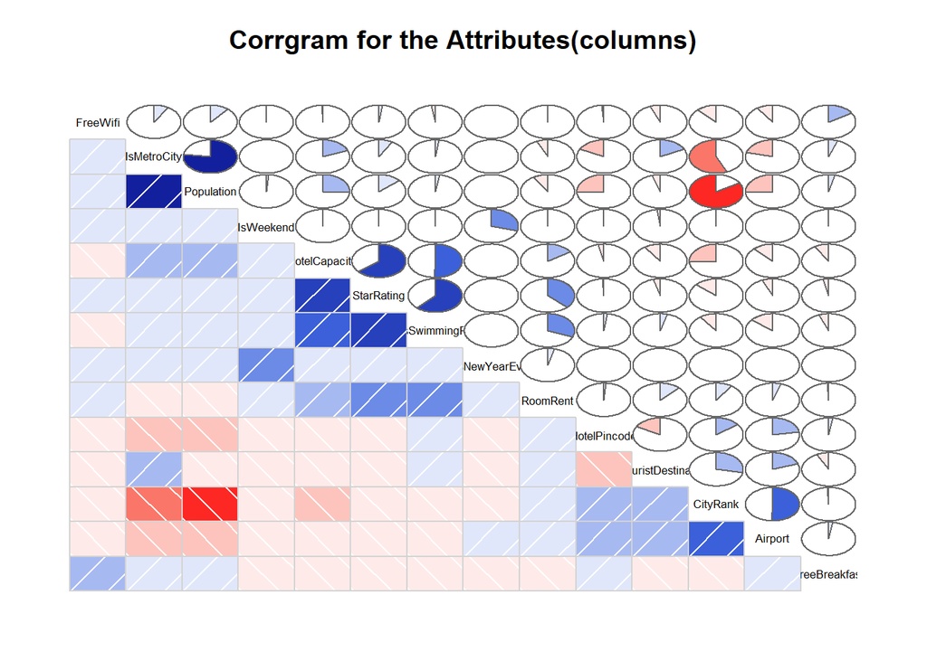

```r
library(corrgram)
corrgram(hotel,main="Corrgram for the Attributes(columns)",
         lower.panel = panel.shade,
         upper.panel=panel.pie,
         order=T,
         text.panel = panel.txt)
```

```r
#Let us find the Correlation Matrix For Rent,Pincode,airport and rating.

x<-hotel[,c("RoomRent","StarRating","Airport","FreeWifi")]

y<-hotel[,c("RoomRent","StarRating","Airport","FreeWifi")]
    cor(x,y)
```

```
##               RoomRent  StarRating     Airport     FreeWifi
## RoomRent   1.000000000  0.36937343  0.04965324  0.003627002
## StarRating 0.369373425  1.00000000 -0.06091918  0.018009594
## Airport    0.049653244 -0.06091918  1.00000000 -0.094523677
## FreeWifi   0.003627002  0.01800959 -0.09452368  1.000000000
```

```r
    cov(x,y)
```

```
##                RoomRent    StarRating      Airport     FreeWifi
## RoomRent   5.377460e+07  2.048375e+03 8287.1785840  6.968633743
## StarRating 2.048375e+03  5.718875e-01   -1.0485276  0.003568375
## Airport    8.287179e+03 -1.048528e+00  518.0133284 -0.563666554
## FreeWifi   6.968634e+00  3.568375e-03   -0.5636666  0.068647130
```

```r
    var(x,y)
```

```
##                RoomRent    StarRating      Airport     FreeWifi
## RoomRent   5.377460e+07  2.048375e+03 8287.1785840  6.968633743
## StarRating 2.048375e+03  5.718875e-01   -1.0485276  0.003568375
## Airport    8.287179e+03 -1.048528e+00  518.0133284 -0.563666554
## FreeWifi   6.968634e+00  3.568375e-03   -0.5636666  0.068647130
```

## Effect Of Star-Rating On Room rent.

```r
library(car)
```

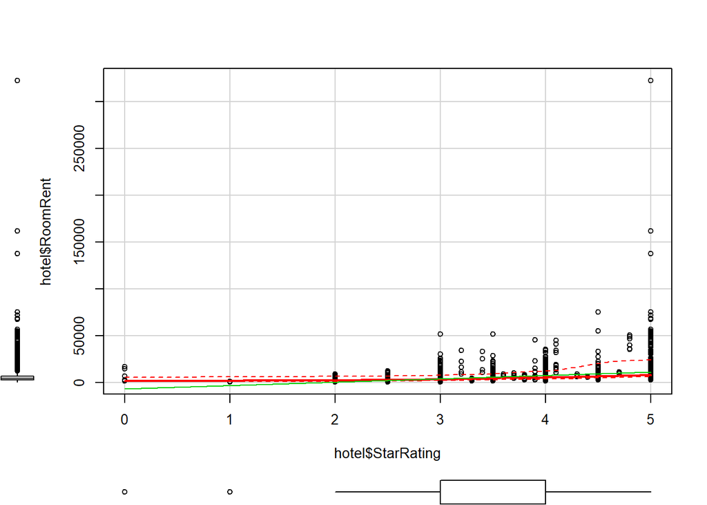

```r
scatterplot(hotel$StarRating,hotel$RoomRent)
```

## Now,let us visualize the above correlation matrix with corrgram.

```r
library(corrgram)
    corrgram(hotel[,c("RoomRent","StarRating","Airport","FreeWifi")],
             order=T,
             lower.panel=panel.shade,
             upper.panel=panel.pie,
             text.panel=panel.txt)
```

[figure not shown]

Test1:- Hypothesis:Average Room rent hotels providing free wifi is greater than which dont provide free wifi.

```r
t.test(hotel$RoomRent ~ hotel$FreeWifi)
```

```
##
##  Welch Two Sample t-test
##
## data:  hotel$RoomRent by hotel$FreeWifi
## t = -0.76847, df = 1804.7, p-value = 0.4423
## alternative hypothesis: true difference in means is not equal to 0
## 95 percent confidence interval:
##  -360.5977  157.5701
## sample estimates:
## mean in group 0 mean in group 1
##        5380.004        5481.518
```

Result:As p-value is greater than 0.05 it suggests that there is no significant difference between the means of our Room rent and Free -Wifi.So,we could not reject null hypothesis.

Test2:- Hypothesis:average Room rent hotels coming from tourist is more than people coming from cities.

```r
t.test(hotel$RoomRent,hotel$IsTouristDestination)
```

```
##
##  Welch Two Sample t-test
##
## data:  hotel$RoomRent and hotel$IsTouristDestination
## t = 85.856, df = 13231, p-value < 2.2e-16
## alternative hypothesis: true difference in means is not equal to 0
## 95 percent confidence interval:
##  5348.337 5598.253
## sample estimates:
##    mean of x    mean of y
## 5473.9918380    0.6971735
```

Test3:- Hypothesis:Average Room rent hotels having free breakfast is more than the hotels which doen’t have any breakfast.

```r
t.test(hotel$RoomRent~hotel$FreeBreakfast)
```

```
##
##  Welch Two Sample t-test
##
## data:  hotel$RoomRent by hotel$FreeBreakfast
## t = 0.98095, df = 6212.3, p-value = 0.3267
## alternative hypothesis: true difference in means is not equal to 0
## 95 percent confidence interval:
##  -153.5017  460.9935
## sample estimates:
## mean in group 0 mean in group 1
##        5573.790        5420.044
```

Result:As p-value is greater than 0.05 it suggests that there is no significant difference between the means of our Room rent and free brerakfast.So,we could not reject null hypothesis.

## Regression Analysis(1)

```r
reg3<-lm(RoomRent~ StarRating +IsMetroCity +FreeBreakfast,data=hotel)
summary(reg3)
```

```
##
## Call:
## lm(formula = RoomRent ~ StarRating + IsMetroCity + FreeBreakfast,
##     data = hotel)
##
## Residuals:
##    Min     1Q Median     3Q    Max
##  -9075  -2438   -968    887 311018
##
## Coefficients:
##               Estimate Std. Error t value Pr(>|t|)
## (Intercept)   -6802.00     290.16 -23.442   <2e-16 ***
## StarRating     3656.73      78.22  46.750   <2e-16 ***
## IsMetroCity   -1568.66     131.25 -11.952   <2e-16 ***
## FreeBreakfast   113.01     123.73   0.913    0.361
## ---
## Signif. codes:  0 '***' 0.001 '**' 0.01 '*' 0.05 '.' 0.1 ' ' 1
##
## Residual standard error: 6779 on 13228 degrees of freedom
## Multiple R-squared:  0.1457, Adjusted R-squared:  0.1455
## F-statistic: 751.8 on 3 and 13228 DF,  p-value: < 2.2e-16
```

```r
reg3$coefficients
```

```
##   (Intercept)    StarRating   IsMetroCity FreeBreakfast
##     -6801.997      3656.730     -1568.661       113.012
```

# Regression Analysis (2)

```r
reg1<-lm(RoomRent~StarRating + Airport + HasSwimmingPool + HotelCapacity + FreeWifi,data=hotel)
summary(reg1)
```

```
##
## Call:
## lm(formula = RoomRent ~ StarRating + Airport + HasSwimmingPool +
##     HotelCapacity + FreeWifi, data = hotel)
##
## Residuals:
##    Min     1Q Median     3Q    Max
## -10799  -2266   -877    967 310428
##
## Coefficients:
##                  Estimate Std. Error t value Pr(>|t|)
## (Intercept)     -7473.711    394.284 -18.955   <2e-16 ***
## StarRating       3517.457    111.686  31.494   <2e-16 ***
## Airport            25.595      2.603   9.831   <2e-16 ***
## HasSwimmingPool  2716.242    158.616  17.125   <2e-16 ***
## HotelCapacity     -14.751      1.006 -14.665   <2e-16 ***
## FreeWifi          210.761    223.335   0.944    0.345
## ---
## Signif. codes:  0 '***' 0.001 '**' 0.01 '*' 0.05 '.' 0.1 ' ' 1
##
## Residual standard error: 6687 on 13226 degrees of freedom
## Multiple R-squared:  0.1689, Adjusted R-squared:  0.1686
## F-statistic: 537.5 on 5 and 13226 DF,  p-value: < 2.2e-16
```

```r
reg1$coefficients
```

```
##     (Intercept)      StarRating         Airport HasSwimmingPool
##     -7473.71059      3517.45652        25.59515      2716.24231
##   HotelCapacity        FreeWifi
##       -14.75071       210.76122
```

## Regression Analysis (3)

```r
reg2<-lm(RoomRent ~ StarRating + Airport + HotelCapacity + IsWeekend + HasSwimmingPool,data=hotel)
summary(reg2)
```

```
##
## Call:
## lm(formula = RoomRent ~ StarRating + Airport + HotelCapacity +
##     IsWeekend + HasSwimmingPool, data = hotel)
##
## Residuals:
##    Min     1Q Median     3Q    Max
## -10800  -2267   -880    980 310462
##
## Coefficients:
##                  Estimate Std. Error t value Pr(>|t|)
## (Intercept)     -7312.691    349.532 -20.921   <2e-16 ***
## StarRating       3522.885    111.535  31.585   <2e-16 ***
## Airport            25.346      2.590   9.786   <2e-16 ***
## HotelCapacity     -14.777      1.006 -14.695   <2e-16 ***
## IsWeekend          40.177    119.938   0.335    0.738
## HasSwimmingPool  2708.404    158.403  17.098   <2e-16 ***
## ---
## Signif. codes:  0 '***' 0.001 '**' 0.01 '*' 0.05 '.' 0.1 ' ' 1
##
## Residual standard error: 6687 on 13226 degrees of freedom
## Multiple R-squared:  0.1688, Adjusted R-squared:  0.1685
## F-statistic: 537.3 on 5 and 13226 DF,  p-value: < 2.2e-16
```

```r
reg2$coefficients
```

```
##     (Intercept)      StarRating         Airport   HotelCapacity
##     -7312.69132      3522.88515        25.34555       -14.77651
##       IsWeekend HasSwimmingPool
##        40.17697      2708.40430
```